# Introduction to Sampling and the CLT

November 05, 2019 @ 05:28 PM

## Before We Begin…

These slides are not meant to be standalone information. You should take notes to flesh out the contents. I recommend that you create an R Markdown document where you can combine information and code from the slides and your own additional notes and explorations to make connections.

**Related Materials**

Refer to "[4.1 ioslides presentation](https://bookdown.org/yihui/rmarkdown/ioslides-presentation.html)" in [*R Markdown: The Definitive Guide*](https://bookdown.org/yihui/rmarkdown/) if you are interested in creating R Markdown slides.

[video not shown]

## Video Sampling Example in R

Create the population and calculate the population mean \(\mu\).

```r
ages <- c(234,241, 233, 227, 251, 227, 242, 239, 241, 238, 230, 246,
          231, 243, 238, 276)
mu <- mean(ages)
```

Set up a loop to take repeated samples. Calculate the mean of each sample and store it in a vector. Here, `sims` is the number of samples we plan to take.

```r
sims <- 10^5
samplemeans <- numeric(sims)
for (i in 1:sims) {
  samplemeans[i] <- mean(sample(ages, 3))
}
```

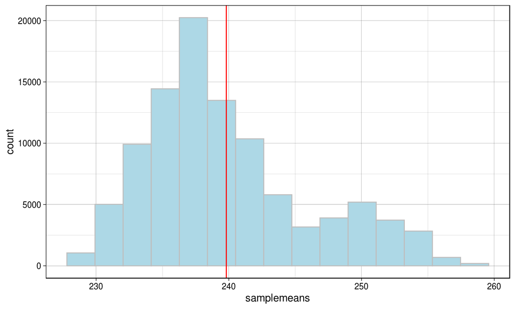

```r
ggplot(NULL, aes(x = samplemeans)) +
  geom_histogram(bins = 15, fill = "lightblue", color = "gray") +
  geom_vline(xintercept = mu, color = "red") + theme_linedraw()
```

We selected three people from the class (without replacement) for each sample. How many unique samples are possible? This can be determined with combinatorics. Let \(N\) be the population size and \(n\) be the sample size.

\[N \text{ choose } n = {N \choose n} = \frac{N!}{n!(N-n)!}\]

\[{16 \choose 3} = \frac{16!}{3!(16-3)!} = \frac{16 \times 15 \times 14 }{3 \times 2 \times 1} = \frac{3360}{6} = 560\]

We can calculate this answer using the `choose()` function in `R`.

```r
choose(16, 3)
```

```
[1] 560
```

[video not shown]

## Video Salary Example Using R

Salaries at a very large corporation have a mean of $62,000 and a standard deviation of $32,000. If a single employee is selected, what is the probability that their salary exceeds $66,000?

```r
pnorm(66000, mean = 62000, sd = 32000, lower.tail = FALSE)
```

```
[1] 0.4502618
```

```r
pnorm(66000, mean = 62000, sd = 32000/sqrt(100), lower.tail = FALSE)
```

```
[1] 0.1056498
```